# California Universal Meal Service Optimization Analysis

David Lang (dnlang86@stanford.edu) and Saurabh Khana (saurabhkhana@stanford.edu)

Abstract: This document utilizes data from the California’s Community Eligibility Provision (CEP) (USDA FN 742) and National Student Lunch Provision Status (NLPS) for the 2019-20 academic year to explore whether or not California Schools are fully utilizing federally subsidized programs for universal meal service. We find that in practice, many school and district are eligible but not currently adopting the program. Optimal partiicipation in these programs would increase universal meal service by in excess of 1.5 million students. We also find that a small but non-trivial fraction of schools should be obligated as a consequence of SB 138. Approximately 200,000 students would receive universal meal service if they were to comply with the senate bill.

## Introduction

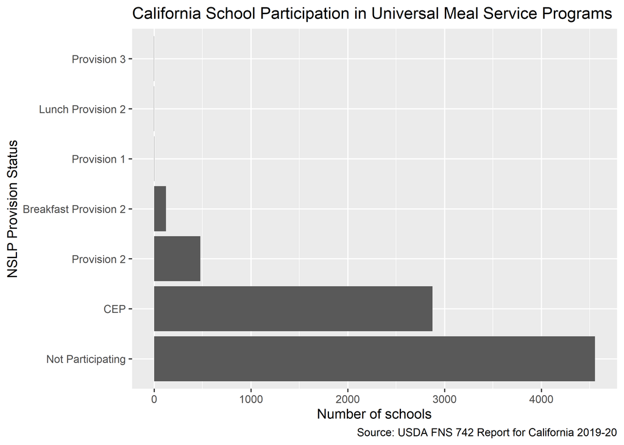

The figures below illustrates the current distribution of schools based on whether or not they qualify for the program on an individual basis. The vertical lines correspond to the 40% threshold at which schools become eligible to participate in the program on an independent basis and 62.5% where schools receive the maximal federal reimbursement rate. Assuming schools must participate in the program independently, over a half-million students could be participating in the program.

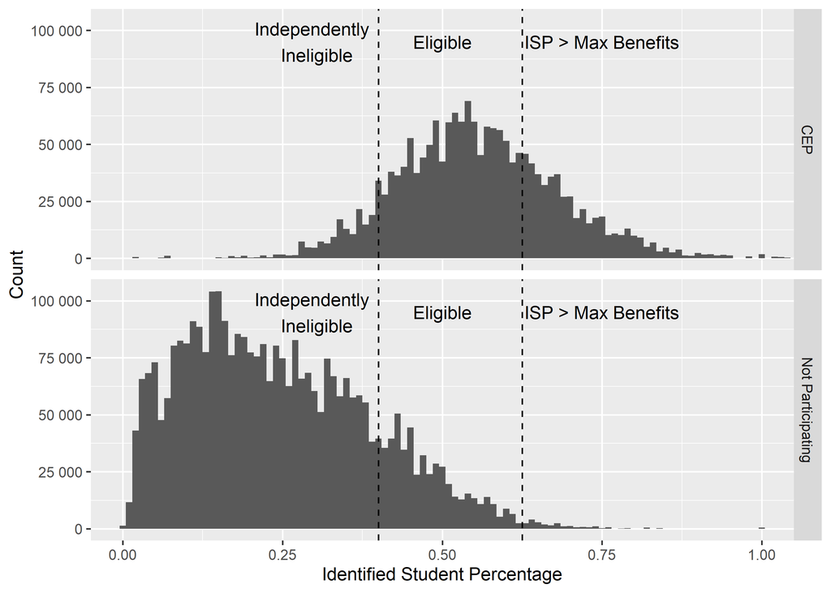

| Eligibility_Type | CEP | Not Participating |
| --- | --- | --- |
| Eligible | 1114708 | 490705 |
| Max Benefits | 483570 | 23068 |
| Not Eligible | 168398 | 2758633 |

Schools tend to participate with increasing probability as the identified student percentage increases. While there an increase in the probability of enrollment, non-parametric tests further suggest that there are sharp discontinuities in participation at the 40% and 62.5% thresholds where the reimbursement policy respectively kick in and level off.

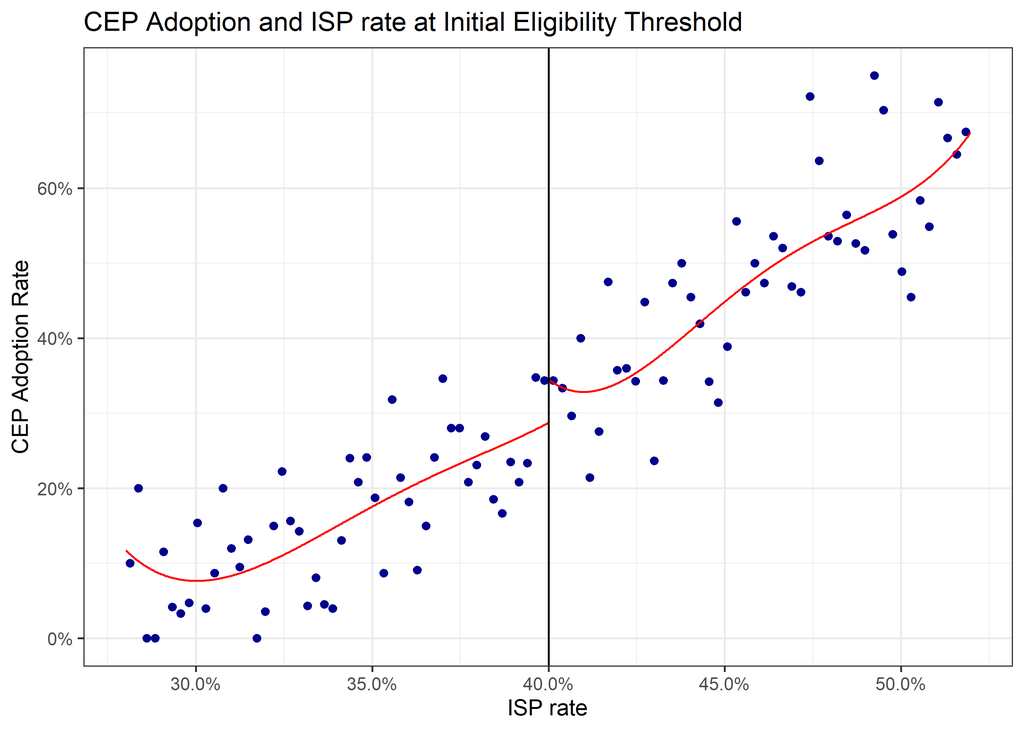

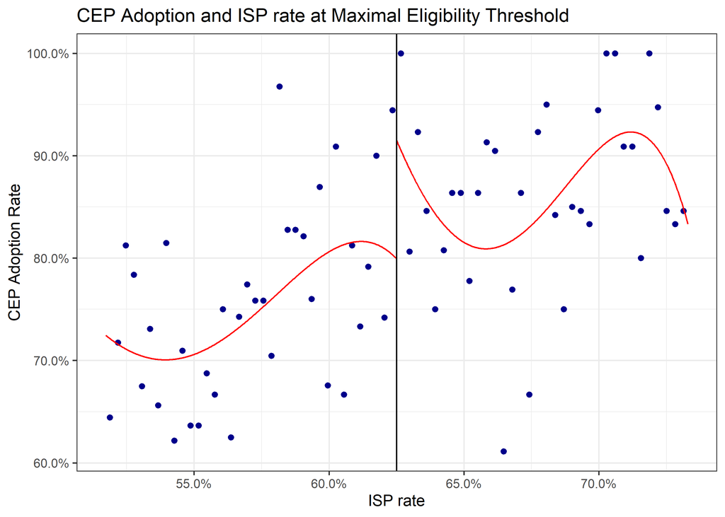

Notably, one of the ways schools can increase their participation is by forming coalitions with other schools in their district such that they can collectively satisfy the requirement.

Below, we perform a simple exercise where we try to build the largest eligible pool of schools that could receive CEP. We build these groups with a simple fairness constraint where we require that each school that participates in CEP must have an ISP rate that is strictly greater than all schools that do not receive the CEP benefit. We also make simplifying assumptions that schools can only form coalitions within their district and that only group of schools per district can participate in CEP. The results of this exercise suggest that nearly 1.8 million students could receive universal meal service with modest supplementary support.

| proposed_eligibility | current_eligibility | district_gain | total_enrollment |
| --- | --- | --- | --- |
| 3348346 | 1558296 | 1790050 | 5422487 |

| Mean Proposed Reimbursement |
| --- |
| 0.7655983 |

| Mean Current Reimbursement |
| --- |
| 0.8909949 |

|  | lea_id | lea_name | total_enrollment | proposed_eligibility | current_eligibility | ISP_proposed | ISP_current | district_gain |
| --- | --- | --- | --- | --- | --- | --- | --- | --- |
| 1 | 1702 | Los Angeles Unified School District | 468924 | 468924 | 286339 | 0.449 | 0.538 | 182585 |
| 2 | 1695 | Long Beach Unified School District | 71492 | 71492 | 0 | 0.454 |  | 71492 |
| 3 | 2081 | Garden Grove Unified School District | 42265 | 42265 | 502 | 0.417 | 0.677 | 41763 |
| 4 | 2462 | San Diego Unified School District | 108313 | 83706 | 45592 | 0.402 | 0.536 | 38114 |
| 5 | 2249 | Elk Grove Unified School District | 62422 | 31698 | 985 | 0.402 | 0.622 | 30713 |
| 6 | 2279 | San Juan Unified School District | 40040 | 34567 | 4276 | 0.409 | 0.762 | 30291 |
| 7 | 2063 | Anaheim Union High School District | 30165 | 30165 | 0 | 0.482 |  | 30165 |
| 8 | 2211 | Riverside Unified School District | 40905 | 34595 | 6608 | 0.402 | 0.543 | 27987 |
| 9 | 1804 | Montebello Unified School District | 25320 | 25320 | 0 | 0.471 |  | 25320 |
| 10 | 2548 | LODI UNIFIED SCHOOL DISTRICT | 28684 | 28101 | 5837 | 0.402 | 0.59 | 22264 |

[output cut: 847 more lines]

We also consider the possibility that districts are not able to reduce their reimbursement rate at all but wish to increase their coverage. If a district already had schools that had over 62.5% ISP, those schools cannot receive additional reimbursement on a per-meal basis but they can lend some of their excess capacity to another school. We perform a narrow search in this space to identify if any schools could lend this capacity while providing no decreases in meal reimbursement rates. We find that nearly 200,000 students could receive universal meal service without adversely affecting reimbursement rates. This policy stems from both encouraging utilization of excess slack and from encouraging schools that are in non-compliance with SB 138, from adopting a universal meal service provision.

| district_gain |
| --- |
| 195436 |

## Discussion

This work suggests that nearly 1.8 million students could receive universal meal service with modest supplementary support. In effect, based on existing levels of financial support from the federal government, state and local governments should be able to cover an additional 3 students for every additional student it decides to cover. Even if no existing financial supports exists, we have identified nearly 200,000 students that could receive universal meal service at the full federally reimbursed rate.

Moreover, these results also suggest that there are likely non-trivial gains that can occur by using more advanced optimization techniques. Currently, all of these analyses used a simple grid search algorithm that works well but are suboptimal.